# Red Squirrel: Data prep, LD-based SNP pruning, PCA, IBD

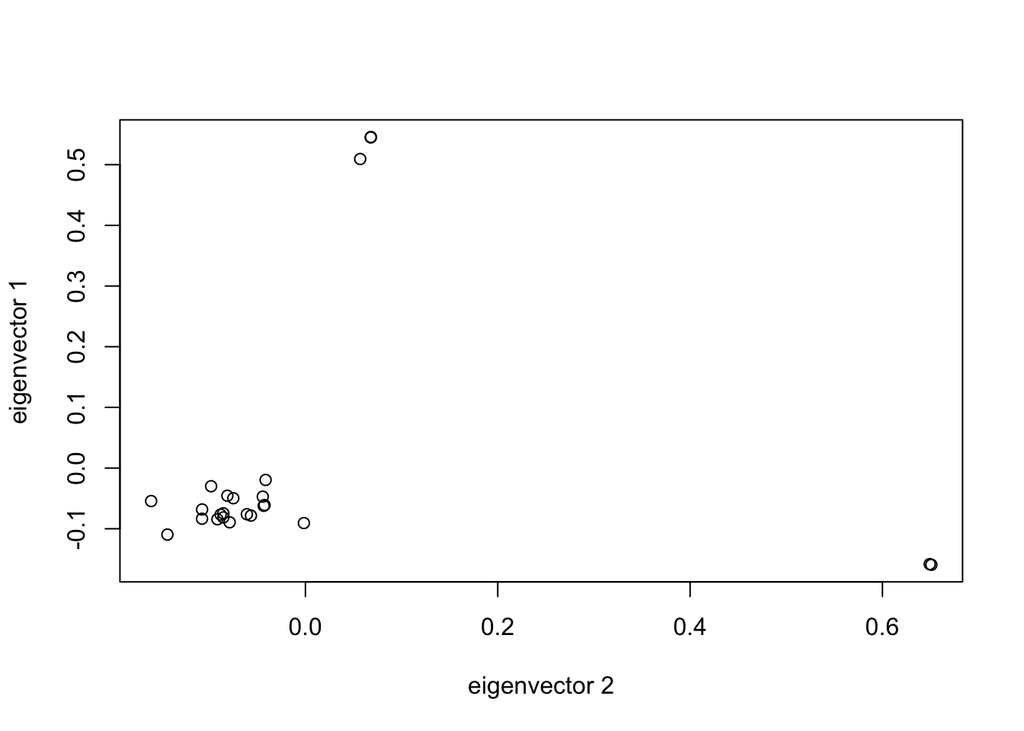

[figure not shown]

```r
plot(tab$EV2, tab$EV1, xlab="eigenvector 2", ylab="eigenvector 1") #three distinct groups
```

Relatedness Analysis: Estimating IBD Using PLINK method of moments (MoM)  
#For relatedness analysis, identity-by-descent (IBD) estimation in SNPRelate can be done by either the method of moments (MoM) (Purcell et al., 2007) or maximum likelihood estimation (MLE) (Milligan, 2003; Choi et al., 2009). For both of these methods it is preffered to use a LD pruned SNP set.

```r
sample.id <- read.gdsn(index.gdsn(genofile, "sample.id"))

# Estimate IBD coefficients
ibd <- snpgdsIBDMoM(genofile, sample.id, snp.id=snpset.id, autosome.only = FALSE, remove.monosnp= TRUE, kinship = TRUE, maf=0.05, missing.rate=0.05, num.thread=2, verbose= TRUE)
```

```
## IBD analysis (PLINK method of moment) on genotypes:
## Excluding 22,916 SNPs (monomorphic: TRUE, MAF: 0.05, missing rate: 0.05)
## Working space: 24 samples, 15,414 SNPs
##     using 2 (CPU) cores
## PLINK IBD:    the sum of all selected genotypes (0,1,2) = 544130
## Tue May 22 09:28:19 2018    (internal increment: 65536)
##
[..................................................]  0%, ETC: ---
[==================================================] 100%, completed in 0s
## Tue May 22 09:28:19 2018    Done.
```

```r
  #maf (minor allele frequency) threshold is the frequency   at which the second most common allele occurs in a given   population.

# Make a dataframe
ibd.coeff <- snpgdsIBDSelection(ibd)
head(ibd.coeff)
```

```
##      ID1     ID2 k0 k1 kinship
## 1 UMA2_1 UMA35_1  1  0       0
## 2 UMA2_1  RS32_1  1  0       0
## 3 UMA2_1 UMA20_1  1  0       0
## 4 UMA2_1 UMA39_1  1  0       0
## 5 UMA2_1 UMA19_1  1  0       0
## 6 UMA2_1 RS104_1  1  0       0
```

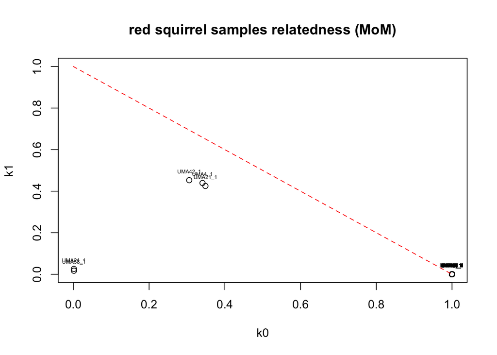

Estimating IBD: Maximum Likelihood Estimation  
#Identical by descent (IBD) describes a matching segment of DNA shared by two or more individuals that has been inherited from a common ancestor without any intervening recombination. Alleles that are IBD have been interested by a recent common ancestor (and indicate recent gene flow).

```r
# Estimate IBD coefficients
set.seed(1) #should be 1000
ibd <- snpgdsIBDMLE(genofile, sample.id = NULL, snp.id=snpset.id,autosome.only = FALSE, remove.monosnp= TRUE, maf=0.05, missing.rate=0.05, kinship = TRUE, num.thread=2, verbose = TRUE)
```

```
## Identity-By-Descent analysis (MLE) on genotypes:
## Excluding 22,916 SNPs (monomorphic: TRUE, MAF: 0.05, missing rate: 0.05)
## Working space: 24 samples, 15,414 SNPs
##     using 2 (CPU) cores
## MLE IBD:    the sum of all selected genotypes (0,1,2) = 544130
## MLE IBD: Tue May 22 09:28:19 2018    0%
```

```r
# Make a dataframe
ibd.coeff <- snpgdsIBDSelection(ibd)
```

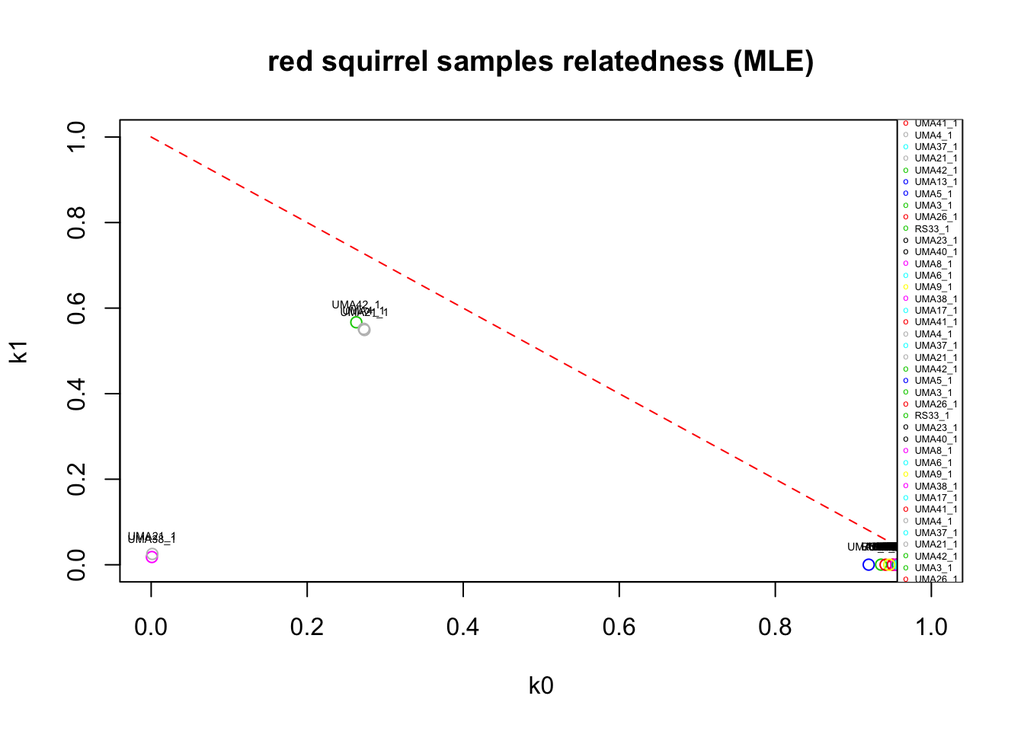